# Study designs for vaccine safety

In vaccine safety surveillance the researcher (or a defined automated system) observes, but does not intervene, with the events that occur. Therefore safety surveillance falls under observational studies. The researcher observes accumulating data related to vaccinations and medical diagnoses and attempts to answer the question: has the rate of adverse events for a vaccinated individual increased due to the exposure.

A natural follow-up question is: increased as compared to what? To answer this question, the researcher needs a *study design* which defines the groups of individuals to be compared. Ideally, the defined groups would only differ with respect to their exposure status, so that observed changes in the rates of events could be directly assigned to the exposure. In practise this is difficult to achieve.

Electronic health care databases such as the hospital discharge register (HILMO) can be utilized as sources of data for medical diagnoses to operationalize the biological condition of interest (adverse event). However, the visit to a hospital resulting in a certain diagnosis code might not directly relate to the adverse event. This can introduce biases when comparing observations from different time periods, due to for example changes in diagnosis coding practises, which are then observed as changes in event rates. The chosen study design should be as robust to these changes as possible.

If the study design is poor and the chosen groups are not comparable, the studied sample can be biased: the observed effect of the exposure may be caused by some other differences between the groups. This means that the rate of false positive or false negative signals generated by the safety surveillance method may be inflated.

In their systematic review of vaccine safety surveillance applications, @Leite2016 found that from 11 recently generated signals, only 3 were confirmed as true signals. The false positive signals were assigned to

1. Confounding factors that have not been considered.
2. Misclassification of the outcome.
3. Changes in the true incidence or coding practises.
4. Inappropriate comparison groups.
5. Uncertainty in background rates.
6. Type I errors. [@Leite2016 p. 234].

All the above reasons except the 2nd one are affected by the study design.

In vaccine safety surveillance, the study design should make it unlikely to introduce biases while enabling the generation of a true signal as reliably as possible. In the following sections, I will first compare possible observational study designs for safety survaillance: Cohort designs, case-control designs and case-only designs. The rest of the chapter will then focus on the two most popular case-only study designs in pharmagovigilance (drug safety): the self-controlled case series (SCCS) and the case-crossover design (CCO).

## Observational epidemiological study designs

Ultimately all epidemiological study designs share the same goal: to compare some group of individuals (cases or exposed) to another group of individuals (controls or unexposed). In vaccine safety surveillance, the question of interest is whether and how the exposure to the vaccine causes an increased risk of an adverse event. The main observations of interest relate to medical diagnoses which occur after exposure. I will consider the following three observational study designs for safety surveillance:

1. **Cohort design**: Time is viewed from the point of view of exposure. Groups of exposed and non-exposed individuals are followed forward in time. The incidences of events are compared between the groups.
2. **Case-control design**: Time is viewed from the point of view of the event. Individuals with events (i.e. cases) are matched to one or more individuals without events (i.e. controls). The proportions of those that have been exposed are compared between the cases and controls.
3. **Case-only designs**: Only individuals with events are sampled and are self-matched, using so called risk and control periods to define the events as either cases or controls. Event incidences or exposure rates are compared between the periods.

The designs have different strengths and weaknesses, some of which are listed in Table 2.1.

Design

Strengths

Weaknesses

**Cohort design**

- Can provide an estimate of the baseline incidence
- Utilizes all available data resulting in high power
- If the exposure rate is high, the unexposed group from the same time period will be small
- Confounders can affect the distribution of exposure, possibly resulting in bias

**Case-control design**

- If matched by age and time , controls for time-varying confounders such as age and seasonality
- Needs little data specially with rare events
- The unexposed group can be small
- Finding suitable matches might be difficult
- Confounders can affect the distribution of exposure, possibly resulting in bias

**Case-only design**

- Self-controlled: eliminates selection biases and confounding related to control subjects and time-invariant characteristics.
- Does not need a baseline incidence estimate
- Needs only data on cases
- The choice of the risk and control periods plays a crucial role
- Time-dependent confounders such as age and seasonality must be explicitly included in the model

### Cohort and case-control designs

The cohort design utilizes all available data and is therefore often a preferred choice if data from the whole population are available. However, the nature of the exposure-event pairs considered here poses problems to cohort designs. One problem is that the exposure to vaccination is optional, possibly resulting in a selection bias. A second problem relates to using medical diagnoses as proxies for the underlying biological condition of interest. I will provide two examples to clarify.

One way to utilize a cohort or a case-control design would be to compare the rates of events between the vaccinated and unvaccinated populations of selected birth cohorts. This would provide a comparison which utilizes all available data from a single time period. The problem with this approach is that vaccination is both optional and usually very popular. Therefore, the group of unvaccinated individuals is often small and possibly biased due to selection. The latter may mean that the observed differences in the rates of events are due to the same reasons that cause individuals to become or not become vaccinated.

A second example of a cohort design would be a comparison of cohorts born before and after the introduction of a new vaccine to a vaccination program. The pre-vaccination era could be used to estimate the baseline incidence of adverse events and the incidence during the post era could then be compared to the baseline. This approach utilizes a great amount of data and provides a seemingly unbiased comparison, assuming that exposure to vaccination is the only significant difference between the cohorts. The problem with this approach is that diagnosis coding practises can change over time due to changes in recommendations or practises. The observed differences in event rates in electronic health care data bases can therefore be simply due to these changes.

### Case-only designs

Case-only designs are designs which utilize data only from cases (individuals with the events of interest). In case-only designs, each individual with an event acts as his/her own control and hence the designs are also called self-controlled designs. The designs considered here are based on comparison of event or exposure rates between predefined risk and nonrisk periods.

In self-controlled designs, comparisons are made within the individuals such that all time-invariant confounders are eliminated [@Nordmann2012]. Simulation studies by both @McClure2008 and @Glanz2006 have found that the self-controlled designs retain relatively high power compared to the cohort and case-control designs despite utilizing less data.

In their systematic review of case-only designs, @Nordmann2012 found that the two most popular case-only designs utilized in pharmacovigilance are the case-crossover design (CCO) and the self-controlled case series design (SCCS). They also remark that “With the development of health care information technology … these designs seem particularily appropriate to analyze pharmacovigilance data”, assuming that the exposure is transient rather than chronic, such as vaccination.

According to @Farrington2004, both CCO and SCCS can and have been used for vaccine safety analysis. According to @Maclure2012, they are better than cohort designs for investigating transient effects of vaccines. In the following sections, I will present the CCO and SCCS. The main focus will be on the SCCS design which is developed for (but not limited to) vaccine safety analysis. CCO and SCCS are both suitable for studying rare adverse events.

### CCO and SCCS

The case-crossover design (CCO) and the self-controlled case series design (SCCS) are two of the most popular case-only designs. Both designs implicitly or explicitly define risk and control periods during which rates of events are of interest. A risk period is a time interval following exposure during which the incidence rate of the adverse event can be thought of being potentially related to the exposure. A control period consists of one or more time intervals during which the incidence rate is assumed to be according to the normal background (baseline) rate of the same individuals.

- **The case-crossover design** (CCO): A case-only study design derived from a case-control design logic. Time is viewed from the point of view of the event. The random variables analysed are retrospectively ascertained exposures.
- **The self-controlled case series design** (SCCS) A case-only study design derived from a cohort design logic. Time is viewed from the point of view of the exposure. The ages at vaccination are regarded as fixed, and the random variable of interest is age at event, conditionally on its occurrence within a pre-determined observation period. [@Farrington2004]

In CCO and SCCS, events occuring during a risk period can be labeled as “cases” and events during the control period as “controls.” Both designs aim at comparing the incidence rates of adverse events between the different periods, “within individuals”. Individuals implicitly act as both cases and controls in the study because the person-time of the individuals is used to define both the cases and the controls.

From a statistical inference point of view, incidence rates can be compared with their ratio, called the *rate ratio*, denoted by $RR$. The rate ratio between two constant incidence rates $\lambda_1$ and $\lambda_0$ is

$$\begin{equation}
RR = \frac{\lambda_1}{\lambda_0}.
\end{equation}$$

The rate ratio is the parameter of interest in both the CCO and SCCS. The SCCS approaches the problem by directly considering the rates of events during different periods of risk (e.g. a risk and a control period). CCO approaches the problem “backwards” by considering the rates of exposure instead. What now follows is a detailed description of the SCCS method followed by a description of CCO.

## The self-controlled case-series design: SCCS

In the self-controlled case series design (SCCS) developed by @Farrington1995, the goal is to compare the relative rates of adverse events during disjoint risk and control time periods, specified in relation to the time of vaccination. The observation period in SCCS is the calendar period and a specified age interval during which individuals can be sampled as cases. The effect of the vaccination is estimated via the rate ratio $RR = \lambda_1 / \lambda_0$, where in a simple case

- $\lambda_1$: the rate of the event during a period when the exposure to vaccination is assumed to have an effect (risk period)
- $\lambda_0$: the rate of the event during a period when the vaccination is assumed to not have an effect (control period).

If there is a significant change in the incidence during the risk period, the rate ratio will differ from 1, with values greater than 1 indicating a positive association between the exposure and the event. Values less than 1 indicate a negative association and are usually not of interest in safety surveillance.

The risk period(s) are defined based on previous knowledge regarding the relationship between the vaccine and the adverse event. In a simple case a single risk period could be a period of two weeks immediately following vaccination. A control period can also be explicitly defined, or alternatively all other time during the observation period can be considered as the control period. See Figure for an illustration of the former.

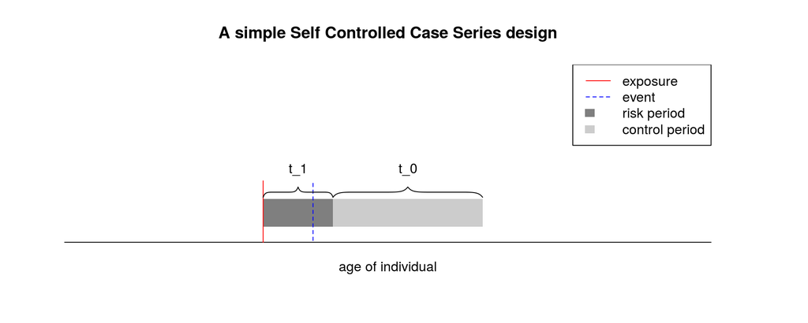

A simple example of a SCCS design where the period immediately following exposure is defined as the risk period with length $t_1$ and a time period following the risk period is defined as the control period with length $t_0$. In this example, the event occurs during the risk period

The general idea of SCCS is to describe the event incidence as a function of the (constant) individual baseline incidence, effects due to vaccine exposure and other possible time-dependent factors such as age. Statistical inference in SCCS is based on a conditional likelihood which removes the individual incidence as a nuisance parameter. Inference concerning relative incidences (rate ratios) can therefore be done “within individuals” so that the individual baseline incidences have no impact on the inference.

In what follows is a mathematical description of SCCS largely inspired by the description of the general SCCS given in the case series tutorial by @Whitaker2006 [pp. 9-10] with influences from the description of SCCS by @Bernardo2011 [pp. 10-12]. I will first give a general framework for the SCCS method by introducing the concepts of a Poisson process and incidence rate function and then describe the conditional likelihood for the parameters of that function.

### Poisson process

An underlying assumption in the SCCS method is that adverse events occur as a Poisson process. A Poisson process describes the probabilities for the numbers of events during some time interval(s). An important assumption related to the Poisson process is that the random variables corresponding to these numbers of events are independent between all disjoint time intervals. This implies that an occurrence of an adverse event should not influence the probabilities of future adverse events. This assumption is likely to be violated in practise, but if the event is rare (relative to the length of the observation period), then this violation is unlikely to have practical consequences.

### Observation period

In SCCS, the observation period for individual $i$ is the time period during which an event could be sampled [@Whitaker2006]. The observation periods could for example be defined by specifying a single calendar time period and an age interval. This definition can lead to observation periods of different lenghts, as the start or end of the calendar time period might shorten the observation period of some individuals.

In this work I will use birth years to specify eligibility. The observation period for eligible individuals is defined by an age interval during which events can be sampled. In this work the smallest measurable unit for time is a day, since data in electronic health care data bases such as AvoHILMO are collected daily. Therefore, for each individual, I will index the observation period by age in days denoted by $d$. A single day has a time unit of 1. If not explicitly mentioned, assume that individuals considered are eligible.

### Incidence rate function

An assumption is made that during the observation period, adverse events for individuals $i = 1, 2, ..., N$ arrive as a non-homogenous piecewise-constant Poisson process. The expected number of events (the incidence rate) for each individual is constant within each day, but can vary between days.

The incidence rate during day $d$ for individual $i$ is given by the incidence rate function $\lambda_{id}$, which depends on a constant individual effect $\phi_i$ and a time-dependent effect $\boldsymbol\theta$. The latter captures exposures to vaccination and can also capture factors such as age and seasonality. The effect of $\theta_d$ is assumed to be multiplicative, so that the incidence rate for individual $i$ during day $d$ is given by

$$\begin{equation}
\lambda_{id} = exp(\phi_i + \theta_d).
\end{equation}$$

Due to the properties of the Poisson process the cumulative incidence over a number of days during the observation period is a sum of the daily incidences. If the incidence stays constant for a period of consequent, say, $t_q$ days, the incidence during that period is given by the number of days times the daily incidence. Assuming that the observation period consists of such disjoint periods, the incidence rates are then given by

$$\begin{equation}
\label{incfunc}
\lambda_{iq} = t_q \cdot exp(\phi_i + \theta_q),
\end{equation}$$

where $\theta_q$ is constant for all $d$ days in period $q$. For example in a simple case as in Figure , where $q \in \{\text{risk period}, \text{control period}\}$, the incidence rate () for any one individual takes on two different values.

### Likelihood

Assume now that events of $i = 1, 2, ..., N$ individuals are sampled, with $n_i \geq 1$ events for each $i$ for a total of $n$ events. Assume that events during the observation period arrive as a Poisson process with an incidence rate as defined in (). Denote the number of events for individual $i$ during period $q$ as $y_{iq}$. The probabilities for the numbers of events during the disjoint intervals $q$ are given by the Poisson distribution: $y_{iq} \sim Poisson(\lambda_{iq})$. The individual contribution to the likelihood function, based on the obsevations, is therefore

$$\begin{equation}
L_i(\boldsymbol\theta)
= P(\boldsymbol{y}_i \mid \phi_i, \boldsymbol\theta)
= \prod_q P(y_{iq} \mid \phi_i, \theta_q)
\propto \exp\{- \sum_q \lambda_{iq}\} \prod_q \left( \lambda_{iq} \right)^{y_{iq}},
\end{equation}$$

where $\lambda_{iq} = t_q \cdot exp(\phi_i + \theta_q)$ as in (). The likelihood contains the individual baseline incidence $\phi_i$ which is a nuisance parameter, since the real interest is in the effect of the vaccination and/or age, captured by $\boldsymbol\theta$.

The total number of events for the individual, $n_i = \sum_q y_{iq}$, turns out to be a sufficient statistic for $\phi_i$, meaning that conditioning on $n_i$ removes the dependency on $\phi_i$. It is therefore convenient to operate with the conditional likelihood instead. Since the random variable corresponding to the total number of events is a sum of Poisson random variables, it is also Poisson distributed: $n_i \sim Poisson(\sum_q \lambda_{iq})$. The individual contribution to the conditional likelihood is

$$\begin{equation}
\label{condlik}
L_i(\boldsymbol\theta \mid n_i)
= P(\mathbf{y}_i \mid n_i, \phi_i, \boldsymbol\theta)
= \frac{P(\mathbf{y}_i \mid \phi_i, \boldsymbol\theta) }{P(n_i \mid \phi_i, \boldsymbol\theta)}
\propto \frac{\prod_q \lambda_{iq}^{y_{iq}}}{\left( \sum_q \lambda_{iq} \right) ^{\sum_{q'} y_{iq'}}}
= \prod_q \left( \frac{ \lambda_{iq} }{ \sum_{q'} \lambda_{iq'} } \right)^{y_{iq}}.
\end{equation}$$

Now, plugging in the incidence rate defined by (), the conditional likelihood is

$$\begin{equation}
\label{condlik2}
L_i(\boldsymbol\theta \mid n_i)
\propto \prod_q \left( \frac{ t_q \cdot e^{\phi_i} \cdot e^{\theta_q}}{ \sum_{q'} t_{q'} \cdot e^{\phi_i} \cdot e^{\theta_{q'}}} \right)^{y_{iq}}
= \prod_q \left( \frac{t_q \cdot e^{\theta_q}}{\sum_{q'} t_{q'} \cdot e^{\theta_{q'}}} \right)^{y_{iq}},
\end{equation}$$

which is a multinomial likelihood where the individual baseline incidences have been canceled out. This means that using the conditional likelihood, the inference concerning the parameter $\boldsymbol\theta$ cannot be influenced by the individual parameters $\phi_i$. In that sense the SCCS design is self-controlled. However, it should be noted that all factors which depend on the time period $q$, such as age, remain. The effect of age can be separately included in the model in the general version of SCCS.

Next I will present the simple and the general SCCS which are both based on the assumptions of a piecewise-constant Poisson process and a conditional likelihood. The simple SCCS is particularily useful for the safety surveillance method BmaxSPRT, to be introduced later. The general SCCS is relevant for future research in developing safety surveillance methods.

### Simple SCCS

Consider an SCCS with a simple incidence rate function where there are two periods of interest: a risk period and a reference control period. Denote these periods by the indicator $k \in \{0, 1\}$ where $1$ indicates the risk period and $0$ indicates the control period.

The risk and control periods are disjoint and of lengths $t_1$ and $t_0$ respectively, and are defined in relation to the time of exposure to vaccination. For example, a time period immediately following vaccination can be defined as a risk period and a time period following the risk period can be defined as a control period, as illustrated in Figure . The incidence rate function () takes the form

$$\begin{equation}
\label{eq:simpleSCCS-incfunc}
\lambda_{ik} = t_k \cdot exp(\phi_i + \psi_k), \quad k = 0, 1.
\end{equation}$$

Assume that during the control period $\psi_0 = 0$ and the incidence is simply determined by the baseline incidence of the individual and by () is given by $t_0 \cdot e^{\phi_i}$. The incidence during the risk period is given by $t_1 \cdot e^{\phi_i} e^{\psi_1}$. The parameter of interest is $\psi_1$ which quantifies the multiplicative effect that exposure has on the incidence, as now $RR = \lambda_{i1} / \lambda_{i0} = e^{\psi_1}$ is the rate ratio of the incidence rates during the risk and control periods.

Now assume that events of $i = 1, 2, ..., N$ individuals are identified. Denote the number of events for individual $i$ during the risk period as $y_{i1}$ and during the control period as $y_{i0}$. Each individual has $n_i = y_{i1} + y_{i0}$ events during the periods of interest and the total number of events during the periods is $n = \sum_i n_i$. According to equation (), the individual contribution to the conditional likelihood for the parameter $\psi_1$ is

$$\begin{equation}
L_i(\psi_1 \mid n_i)
\propto
\prod_{k = 0,1} \left( \frac{t_k \cdot e^{\psi_k}}{\sum_{k'} t_{k'} \cdot e^{\psi_{k'}}} \right)^{y_{ik}}
= \left( \frac{ e^{\psi_1} }{ e^{\psi_1} + t_0/t_1 } \right) ^{y_{i1}}
\left( \frac{ t_0 / t_1 }{ e^{\psi_1} + t_0/t_1 } \right)^{n_i - y_{i1}}.
\end{equation}$$

which is the binomial likelihood, where the only unknown parameter is the common rate ratio $RR = e^{\psi_1}$. If one labels the events that occured during the risk period as “cases”, and the events that occured during the control period as “controls”, the probability of an event labeled as a case depends only on $RR$ and the ratio of the lengths of the two periods $z = t_0 / t_1$. The probabilities of a “case” (“success”) and “control” (“failure”) are given by

$$\begin{equation}\label{eq:p}
P("case") = p = \frac{RR}{RR + z}, \quad P("control") = 1-p = \frac{z}{RR + z}.
\end{equation}$$

Assuming that individuals are independent, the total conditional likelihood can be seen as independent binomial trials with a homogenous probability of success, $p = RR / (RR + z)$. Given that observations included $y_1 = \sum_i y_{i1}$ “cases”, the total conditional likelihood for the parameter $RR$ is

$$\begin{equation}\label{eq:SCCS-binomial}
L(RR \mid n) = P(y_1 \mid RR, n) \propto \left( \frac{RR}{RR + z} \right)^{y_1} \left( \frac{z}{RR + z}\right)^{n - y_1}.
\end{equation}$$

### General SCCS

I will now present a more general version of SCCS, including an age effect parameter and multiple risk periods with varying risks. Varying risks can be motivated by for example the desire to include the effects of different doses of a vaccine. The inclusion of an age effect is motivated by the fact that many biological conditions are age-dependent.

Assume again that adverse during the observation period arrive according to a piecewise-constant Poisson process with an incidence rate function similar to (). The observation period for each individual is split into disjoint intervals by age groups indexed by $j$ and disjoint risk periods indexed by $k$. The number of days that individual $i$ spends in risk/control interval $k$ while belonging to age group $j$ is denoted by $t_{ijk}$. The incidence rate function for $i$ can then be written as

$$\begin{equation}
\lambda_{ijk} = t_{ijk} \cdot exp(\phi_i + \gamma_j + \psi_k),
\end{equation}$$

where for the reference age group $\gamma_0 = 0$ and for the reference risk period (control period) $\psi_0 = 0$. Now denote the number of events observed during interval ($jk$) by $y_{ijk}$. The individual contribution to the conditional likehood () is

$$\begin{equation}
L_i(\boldsymbol\psi, \boldsymbol\gamma \mid n_i)
\propto
\prod_{jk} \left( \frac{t_{ijk} \cdot e^{\gamma_j}\cdot e^{\psi_k}} {\sum_{j'k'} t_{{ij'k'}} \cdot e^{\gamma_{j'}} \cdot e^{\psi_{k'}}} \right)^{y_{ijk}}.
\end{equation}$$

Assuming that individuals are independent, the total conditional likelihood is

$$\begin{equation}
L(\boldsymbol\psi, \boldsymbol\gamma \mid \boldsymbol{n})
\propto
\prod_i\prod_{jk} \left( \frac{t_{ijk} \cdot e^{\gamma_j}\cdot e^{\psi_k}} {\sum_{j'k'} t_{{ij'k'}} \cdot e^{\gamma_{j'}} \cdot e^{\psi_{k'}}} \right)^{y_{ijk}},
\end{equation}$$

which, again, is the multinomial likelihood where all the individual baseline incidences have been cancelled out.

## The case-crossover design: CCO

The most popular case-only design utilised in pharmacovigilance is the case-crossover design (CCO). CCO is a modification of a case-control design, originally developed by @Maclure1991 to study the effect of transient exposures to acute events. Its use in drug safety studies has increased during 2000-2010 [@Nordmann2012]. CCO has also been used for vaccine safety analysis [@Farrington2004 p. 2066].

### Description of CCO

Following @Maclure2012 [pp. 50-51], one way to describe the CCO design is as follows: Assume that rare events are observed for individuals $i = 1, .., N$. Each event occurs during some *event day* and a *control day* is defined as the day $d$ time units (e.g. days) before the event day. For example, the control day could be two weeks (14 days) before the event day. For each sampled individual $i$, exposure status is retrospectively examined. Exposures during a time interval of length $t$ immediately preceding the event day are considered as related to the event. Exposures occuring during a time interval of the same length ($t$) immediately preceding the control day are considered as not related to the event.

The periods where the exposure status is of interest are sometimes called risk and control periods in CCO literature. I will call these periods the *related period* and the *non-related period*, respectively. The idea of the CCO design is to compare the rates of exposure between the related and the non-related periods. This description of CCO is illustrated in Figure .

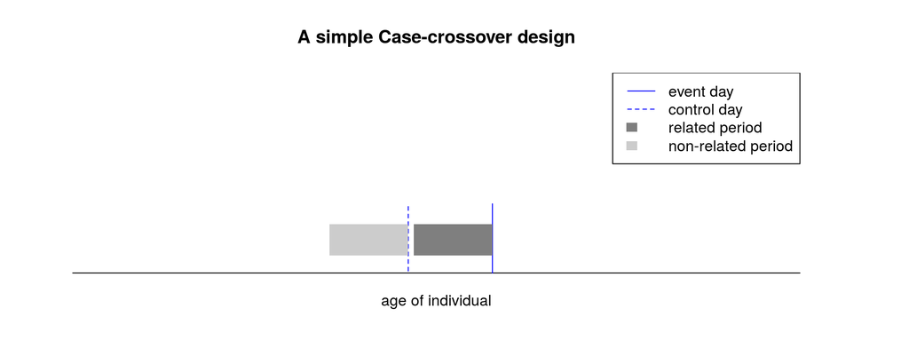

A graphical illustration of the CCO design. Exposures occuring immediately before the event day are considered as related to the event and exposures occuring immediately before the control day are considered as not related to the event.

### Prospective and retrospective arguments

The description of CCO given above follows the so-called retrospective conditional argument of case-control studies. In the retrospective probability model, the exposures are conditioned by the case or control status and the odds ratio of exposure between different event status (“case” or “control”) is the parameter of interest. However, the estimation of disease-exposure relationship in case-control studies may also be approached using a prospective conditional argument. In the prospective probability model, the event status is conditioned on the exposure and the odds ratio of the event status between levels of exposure is estimated [@ClaytonHills, ch. 16].

From a prospective point of view, a time interval following exposure is called the *effect period* in CCO literature, during which the rate of events for the exposed individuals is possibly increased. The effect period corresponds to the related period and is of identical length. The effect period in CCO is comparable to the risk period in SCCS. I will therefore use the term risk period to refer to the effect period. Similarily, a control period of identical length to the non-related period can be defined.

For example, the risk period could be a period of two weeks following vaccination, in which case the related period is the period two weeks prior to the event day. A control period could be defined as the period of two weeks following the risk period, in which case the control day would be the day two weeks prior to the event day and the non-related period would be the period two weeks prior to the control day. See again Figure for an illustration.

The question of interest in both CCO and SCSS is the same, i.e., to infer whether the rate of events is affected by exposure. Although the CCO method is based on the idea of exposures as the random variable, the parameter of interest can be defined as any of the prospective relative risk parameters: the odds ratio, relative risk or the incidence rate ratio [@Nordmann2012 p.8].

### CCO in the literature

The literature concerning the CCO approach may be confusing as the reader may have to interpret from the context whether the author has chosen to treat the design from a prospective or retrospective point of view and sometimes both views are used simultaneously. For example, @Nordmann2012 [p. 2] describe the method using phrasing *“With this design, the probability of exposure in the risk period is compared to the probability of exposure in control period(s).”*. They however then go on to state that *“same probability of event occurrence during case and control periods”* is a major assumption of the method.

When discussing CCO, @Farrington2004 instead writes that *“the underlying probability of vaccination should be the same in all intervals”*, which is in line wih treating exposure as the random variable of interest. @Farrington2004 [p. 2066] then adds that this assumption *“is unlikely to hold for paediatric vaccines administered according to stricter schedules”*.

To estimate the relative risk in the CCO setting, @Maclure1991 suggests using the Mantel-Haenzel estimator to approximate the rate ratio parameter. Further discussion of maximum likelihood estimation in the CCO setting is provided by @Marshall1993.

## Study design conclusions

Cohort designs are problematic for vaccine safety studies due to many possible sources of bias. Case-only designs are attractive because they implicitly control for time-invariant confounders.

Of the two most popular case only designs, SCCS compares somewhat favourably to CCO. @Farrington2004 [p. 2066] has pointed out that in the case of paediatric vaccines there is a conceptual problem with the CCO design, where vaccination times are treated as random variables. It is more natural to view event times as the random variables of interest, since vaccinations often occur according to a strict schedule.

SCCS assumes that the vaccination time is fixed and the time of the adverse event is a random variable of interest. SCCS allows for direct inference concerning the population parameter of interest, which is the relative rate of adverse event incidences between specified risk and control time periods. The simple SCCS introduced in offers a statistical model where the rate ratio $RR$ is the only unknown parameter and fixed individual covariates have no effect on the inference. The likelihood function is binomial.

The following chapter continues discussion of safety surveillance from the point of view of the decision element. The simple SCCS is adopted as the design element.